# The Federal Reserve’s LSAP Program: A Predictive Approach Post the 2008 Financial Crisis

Boston College: Predictive Analytics

Authors: Ivan Lozano

Date: May 11, 2019

# 1 Introduction

1. Motivation: The reason behind investigating the effects that quantitative easing had on the housing market is due to eveidence in history showing how monetary policy intervention had an influence on mortgage rates and home prices.
2. Objectives: The objective of this project will be to use predictive power and machine learning to estimate the prior, current and future effect that the Federal Reserve’s large-scale asset program had on the average housing prices in the US. While there were several key players in the 2008 housing crisis and the recovery, it is clear that the Federal Reserve helped through their Quantitative Easing program. This paper will aim to analyze the effects of buying up treasuries and MBS products on mortgage rate and housing prices. The primary models that will be used are predictive models that will take on historical data. The end of the analysis will include regression models that will aim to estimate the economic impact that expansionary monetary policy has on the housing prices.
3. Organizational overview: We will start the analysis of our data by explaining some of the despcriptive statistics of the data collected. This will allow us to decipher the trends in prices of homes, mortgage rates and the movement of buying and selling of securities that have a direct impact on the US economy. The next part of our analysis will be to portray the time-series and to run some predictive models to show how the data will change in the future. The final part of our analysis will be to analyze the comparison of previously analyzed data in our literature review.

## 1.1 Structure of this paper is as indicated

**Effects of QE**

1. Outline
   - Data Cleaning
   - Descriptive Statistics
   - Modeling
   - Conclusion

## 1.2 Reading in the data - Training

Step 1: I am going to load up the training data for this excercise.

Description: Below we can see what the data looks like in our training data for our two main training datasets. Based on the display we can see that we are dealing with data. For our mortgage rate data we can see that there are several missing values for 15-year, and 1-year fixed rates. Our mortgage rate data also starts much earlier, dating back to 1971, which may be a reason for the earlier missing data. We will have to find a common date when we merge our datsets for further analysis.

```r
pathToTrainingData <- paste0(RawData, "/fredgraph.csv")
mbsTrain <- data.table(read.csv(pathToTrainingData, sep=',', stringsAsFactors = F))

pathToTrainingData2 <- paste0(RawData, "/cleandt2.csv")
mortTrain <- data.table(read.csv(pathToTrainingData2, sep=',', stringsAsFactors = F))

pathToTraingData3 <- paste0(RawData, "/dgs19.csv")
treas_10yr <- data.table(read.csv(pathToTraingData3, sep=',', stringsAsFactors = F))

pathToTraingData4 <- paste0(RawData, "/hpi_case_cpi.csv")
hpi_cpi <- data.table(read.csv(pathToTraingData4, sep=',', stringsAsFactors = F))

pathToTrainingData5 <- paste0(RawData, "/payems.csv")
nfp_rate <- data.table(read.csv(pathToTrainingData5, sep=',', stringsAsFactors = F))

pathToTrainingData6 <- paste0(RawData, "/ism_index.csv")
ism <- data.table(read.csv(pathToTrainingData6, sep=',', stringsAsFactors = F))

kable(head(mbsTrain,5))
```

| DATE | WSHOMCB | TREAST |
| --- | --- | --- |
| 2002-12-18 | 0 | 629397 |
| 2002-12-25 | 0 | 629402 |
| 2003-01-01 | 0 | 629406 |
| 2003-01-08 | 0 | 629406 |
| 2003-01-15 | 0 | 629406 |

```r
kable(head(mortTrain,5))
```

| week | yr30_fixed | yr15_fixed | yr1_treas | yr1_margin |
| --- | --- | --- | --- | --- |
| 4/2/1971 | 7.33 | NA | NA | NA |
| 4/9/1971 | 7.31 | NA | NA | NA |
| 4/16/1971 | 7.31 | NA | NA | NA |
| 4/23/1971 | 7.31 | NA | NA | NA |
| 4/30/1971 | 7.29 | NA | NA | NA |

```r
kable(head(treas_10yr,5))
```

| DATE | DGS10 |
| --- | --- |
| 12/18/2002 | 4.0840 |
| 12/25/2002 | 3.9650 |
| 1/1/2003 | 3.8525 |
| 1/8/2003 | 4.0500 |
| 1/15/2003 | 4.1400 |

```r
kable(head(hpi_cpi,5))
```

| date | real_hpi | nominal_hpi | cpi |
| --- | --- | --- | --- |
| 1/1/2001 | 133.4612 | 109.215 | 175.1 |
| 2/1/2001 | 133.4507 | 109.643 | 175.8 |
| 3/1/2001 | 134.0610 | 110.395 | 176.2 |
| 4/1/2001 | 134.5622 | 111.248 | 176.9 |
| 5/1/2001 | 135.1064 | 112.203 | 177.7 |

## 1.3 Data Cleaning

This part of the paper will involve data cleaning. This will consist of renaming the variables, understanding the data type, and noting any missing values from each of our seperate datasets. We will also change the format of our data into time-series data, so that we can use forecasting analysis.

```r
# This part will consist of renaming and setting our data to a time-series format so we can set time-series
# forecasting models

setnames(mbsTrain, old=c("DATE", "WSHOMCB", "TREAST"),
         new=c("date", "mbs_bal","treas_bal"))

setnames(treas_10yr, old=c("DATE", "DGS10"),
         new=c("date", "treas_10"))

mbsTrain$date <- as.Date(mbsTrain$date, "%Y-%m-%d")
mortTrain$week <- as.Date(mortTrain$week, "%m/%d/%Y")
treas_10yr$date <- as.Date(treas_10yr$date, "%m/%d/%Y")
hpi_cpi$date <- as.Date(hpi_cpi$date, "%m/%d/%Y")


mbsTrain$date <- NULL
mortTrain$week <- NULL
treas_10yr$date <- NULL
hpi_cpi$date <- NULL

mbsTrain1 <- ts(mbsTrain, start=c(2002,12,18), frequency = 52.18) ## Weekly
mortTrain1 <- ts(mortTrain, start=c(1971,4,2), frequency = 52.18) ## Weekly
treas_10yr1 <- ts(treas_10yr, start=c(2002,12,18), frequency = 52.18) ## Weekly
hpi_cpi1 <- ts(hpi_cpi, start=c(2001,1,1), frequency = 12) ## Monthly

str(mbsTrain)
```

```
## Classes 'data.table' and 'data.frame':   848 obs. of  2 variables:
##  $ mbs_bal  : num  0 0 0 0 0 0 0 0 0 0 ...
##  $ treas_bal: num  629397 629402 629406 629406 629406 ...
##  - attr(*, ".internal.selfref")=<externalptr>
```

```r
str(mortTrain)
```

```
## Classes 'data.table' and 'data.frame':   2492 obs. of  4 variables:
##  $ yr30_fixed: num  7.33 7.31 7.31 7.31 7.29 7.38 7.42 7.44 7.46 7.52 ...
##  $ yr15_fixed: num  NA NA NA NA NA NA NA NA NA NA ...
##  $ yr1_treas : num  NA NA NA NA NA NA NA NA NA NA ...
##  $ yr1_margin: num  NA NA NA NA NA NA NA NA NA NA ...
##  - attr(*, ".internal.selfref")=<externalptr>
```

```r
str(hpi_cpi)
```

```
## Classes 'data.table' and 'data.frame':   218 obs. of  3 variables:
##  $ real_hpi   : num  133 133 134 135 135 ...
##  $ nominal_hpi: num  109 110 110 111 112 ...
##  $ cpi        : num  175 176 176 177 178 ...
##  - attr(*, ".internal.selfref")=<externalptr>
```

```r
str(treas_10yr)
```

```
## Classes 'data.table' and 'data.frame':   837 obs. of  1 variable:
##  $ treas_10: num  4.08 3.96 3.85 4.05 4.14 ...
##  - attr(*, ".internal.selfref")=<externalptr>
```

```r
sapply(mbsTrain, function(x) sum(is.na(x)))
```

```
##   mbs_bal treas_bal
##         0         0
```

```r
sapply(mortTrain, function(x) sum(is.na(x)))
```

```
## yr30_fixed yr15_fixed  yr1_treas yr1_margin
##          0       1065       1762       1762
```

```r
sapply(hpi_cpi, function(x) sum(is.na(x)))
```

```
##    real_hpi nominal_hpi         cpi
##           2           2           2
```

```r
sapply(treas_10yr, function(x) sum(is.na(x)))
```

```
## treas_10
##        0
```

## 1.4 Descriptive statistics

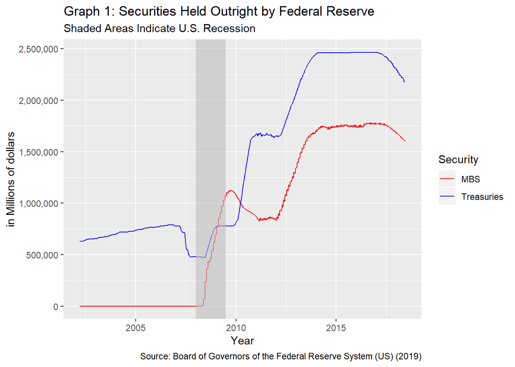

```r
mt_dta <- autoplot(mbsTrain1) +
  xlab("Year") + ylab("in Millions of dollars") +
  ggtitle("Graph 1: Securities Held Outright by Federal Reserve") + labs(subtitle="Shaded Areas Indicate U.S. Recession")

mt_dta + labs(colour = "Security") + labs(caption="Source: Board of Governors of the Federal Reserve System (US) (2019)") +
  scale_color_manual(labels = c("MBS", "Treasuries"), values = c(2, 4)) + scale_y_continuous(label=comma)+       geom_line() +
  annotate("rect", fill = "grey", alpha = 0.6,
           xmin = 2007 + 12/12, xmax = 2009 + 06/12,
           ymin = -Inf, ymax = Inf)
```

Graph 2 data is collected from Freddie Mac and it show’s the changes in interest-rates of typical 30-year, 15-year fixed mortgage rates. I have also included 1 year treasury rates, and 1 year margin rates, but these will be dropped from the final analysis of the dataset. It is important to note how large the 30-year fixed mortgage rates fluctuate over time and upon recessions. When we go to run modeling on the merged files we will be taking only values from 2002 and on to avoid any missing data, but also to standardize the combined sets into monthly data.

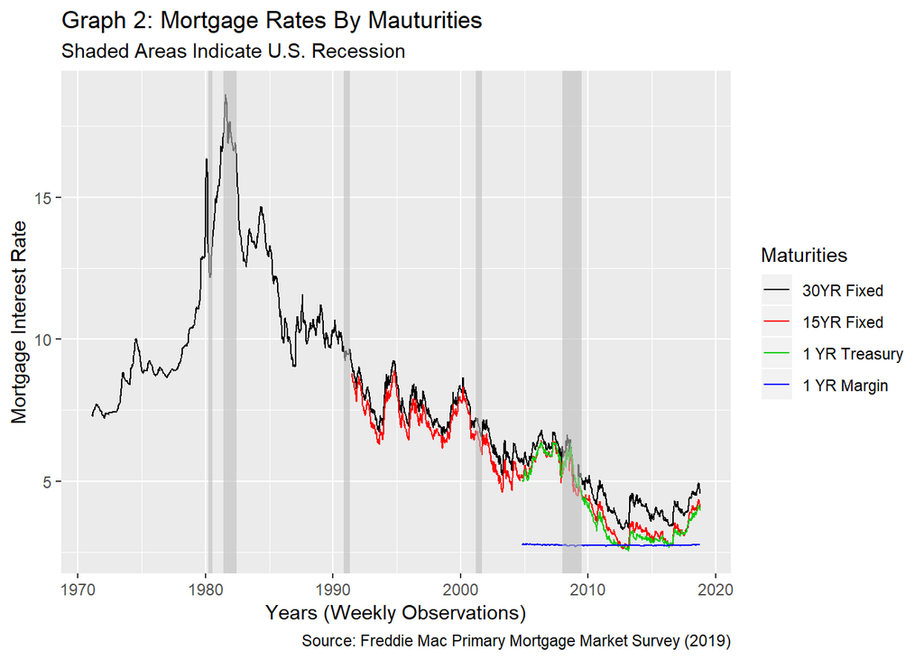

```r
mort_plt <- autoplot(mortTrain1) +
  xlab("Years (Weekly Observations)") + ylab("Mortgage Interest Rate") +
  ggtitle("Graph 2: Mortgage Rates By Mauturities") + labs(subtitle="Shaded Areas Indicate U.S. Recession") +
  labs(caption="Source: Freddie Mac Primary Mortgage Market Survey (2019)")

mort_plt + labs(colour = "Maturities") +
  scale_color_manual(labels = c("30YR Fixed", "15YR Fixed", "1 YR Treasury", "1 YR Margin")
                     , values = c(1, 2, 3, 4))+ geom_line() +
  annotate("rect", fill = "grey", alpha = 0.6
           , xmin = c(1980 + 01/4, 1981 + 03/7, 1990 + 06/7, 2001 + 02/3, 2007 + 12/12)
           , xmax = c(1980 + 04/7, 1982 + 05/11, 1991 + 01/3, 2001 + 02/11, 2009 + 06/12),
           ymin = -Inf, ymax = Inf)
```

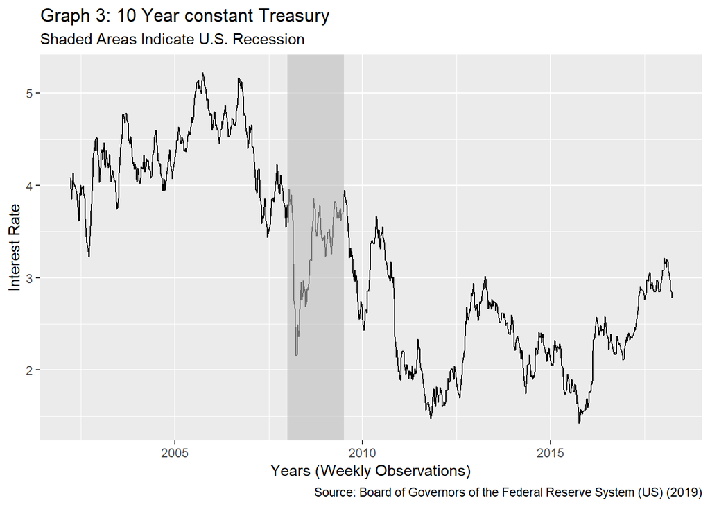

```r
treas_plt <- autoplot(treas_10yr1) +
  xlab("Years (Weekly Observations)") + ylab("Interest Rate") +
  ggtitle("Graph 3: 10 Year constant Treasury") + labs(subtitle="Shaded Areas Indicate U.S. Recession")+labs(caption="Source: Board of Governors of the Federal Reserve System (US) (2019)")

treas_plt + labs(colour = "Maturities") +
  scale_color_manual(labels = c("10YR Treas")
                     , values = c(1, 2, 3, 4))+ geom_line() +
  annotate("rect", fill = "grey", alpha = 0.6
           , xmin = c(2007 + 12/12)
           , xmax = c(2009 + 06/12),
           ymin = -Inf, ymax = Inf)
```

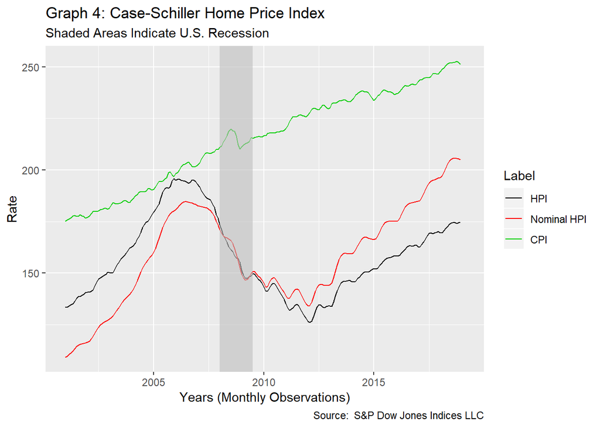

```r
hpi_plt <- autoplot(hpi_cpi1) +
  xlab("Years (Monthly Observations)") + ylab("Rate") +
  ggtitle("Graph 4: Case-Schiller Home Price Index") + labs(subtitle="Shaded Areas Indicate U.S. Recession")+labs(caption="Source:  S&P Dow Jones Indices LLC")

hpi_plt + labs(colour = "Label") +
  scale_color_manual(labels = c("HPI", "Nominal HPI", "CPI")
                     , values = c(1, 2, 3, 4))+ geom_line() +
  annotate("rect", fill = "grey", alpha = 0.6
           , xmin = c(2007 + 12/12)
           , xmax = c(2009 + 06/12),
           ymin = -Inf, ymax = Inf)
```

Now, that we have displayed ll of our time-series plots, let’s subset and merge our datasets to get 1 complete dataset. One note to make is that our subsetted data will start from 2002 and on.

```r
mbsTrain2 <- data.table(read.csv(pathToTrainingData, sep=',', stringsAsFactors = F))
mortTrain2 <- data.table(read.csv(pathToTrainingData2, sep=',', stringsAsFactors = F))
treas_10yr2 <- data.table(read.csv(pathToTraingData3, sep=',', stringsAsFactors = F))
hpi_cpi2 <- data.table(read.csv(pathToTraingData4, sep=',', stringsAsFactors = F))

mortTrain2$yr1_treas <- NULL
mortTrain2$yr1_margin <- NULL
hpi_cpi2$nominal_hpi <- NULL
hpi_cpi2$cpi <- NULL

setnames(mbsTrain2, old=c("DATE", "WSHOMCB", "TREAST"),
         new=c("date", "mbs_bal","treas_bal"))

setnames(treas_10yr2, old=c("DATE", "DGS10"),
         new=c("date", "treas_10"))

mbsTrain2[,dummy:=.I]
mortTrain2[,dummy:=.I]
treas_10yr2[,dummy:=.I]
hpi_cpi2[,dummy:=.I]

hpi_cpi3 <- subset(hpi_cpi2, dummy >= 24)
mortTrain3 <- subset(mortTrain2, dummy >= 1654)

mbsTrain2$date <- as.Date(mbsTrain2$date, "%Y-%m-%d")
mortTrain3$week <- as.Date(mortTrain3$week, "%m/%d/%Y")
treas_10yr2$date <- as.Date(treas_10yr2$date, "%m/%d/%Y")
hpi_cpi3$date <- as.Date(hpi_cpi3$date, "%m/%d/%Y")

setnames(mortTrain3, old="week", new = "date")

x_test <- merge(mbsTrain2, treas_10yr2)
x_test$dummy <- NULL
x_test[,w_1:=week(date)]
x_test[,y_1:=year(date)]
mortTrain3$dummy <- NULL
mortTrain3[,w_1:=week(date)]
mortTrain3[,y_1:=year(date)]

x2_test <- merge(mortTrain3, x_test
                 , by.x=c("w_1","y_1")
                 , by.y=c("w_1","y_1"), all.x=TRUE)

x2_test[!complete.cases(x2_test), ] #We have some NA values, which appears that we can drop them as they are extra generated variables
```

```
##    w_1  y_1     date.x yr30_fixed yr15_fixed date.y mbs_bal treas_bal
## 1:  49 2002 2002-12-06       6.19       5.60   <NA>      NA        NA
## 2:  50 2002 2002-12-13       6.04       5.46   <NA>      NA        NA
## 3:  53 2010 2010-12-30       4.86       4.20   <NA>      NA        NA
## 4:  53 2016 2016-12-29       4.32       3.55   <NA>      NA        NA
##    treas_10
## 1:       NA
## 2:       NA
## 3:       NA
## 4:       NA
```

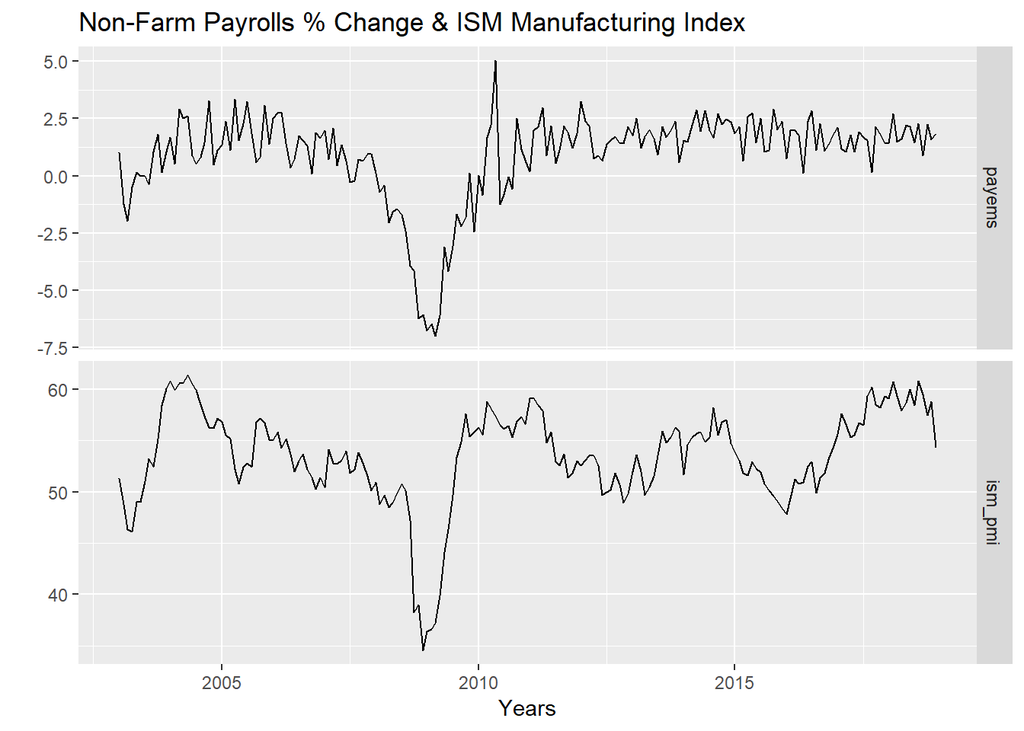

```r
x2_test <- na.omit(x2_test)

hpi_cpi3[,w_1:=week(date)]
hpi_cpi3[,y_1:=year(date)]
hpi_cpi3[,m_1:=month(date)]

hpi_cpi3$dummy <- NULL

x2_test[,m_1:=month(date.x)]

# x3_test <- merge(x2_test, hpi_cpi3
#                  , by.x=c("m_1", "y_1")
#                  , by.y=c("m_1", "y_1"), all.x=TRUE)
#
# x3_test[, c("m_1","y_1","date","w_1.y","w_1.x","date.y"):=NULL]
#
# setnames(x3_test, old = "date.x", new = "date")

# THIS IS GOING TO BE CORRECT THIS TIME#
x2_test[, mix_d:=paste0(m_1,y_1)]

d1 <- x2_test[,.(yr_15_fixed=mean(yr15_fixed)
                 , yr_30_fixed=mean(yr30_fixed)
                 , mbs1=mean(mbs_bal)
                 , treas1=mean(treas_bal)
                 , treas_10=mean(treas_10)), by = mix_d]

hpi_cpi3[, mix_d:=paste0(m_1,y_1)]
hpi_cpi3 <- hpi_cpi3[-c(194:195)]
cmb_master <- merge(hpi_cpi3,d1
                 , by.x=c("mix_d")
                 , by.y=c("mix_d"), all.x=TRUE)
cmb_master <- cmb_master[(-49)]
cmb_master <- cmb_master[order(cmb_master$date)]
cmb_master[,c("w_1") := NULL]
####### Let's also include some macroeconomic variables, to be discussed #####

ism<-ism[-c(194:197)]
ism<-ism[-1]
nfp_rate<-nfp_rate[-1]

nfp_rate$date <- as.Date(nfp_rate$date, "%m/%d/%Y")
ism$date <- as.Date(ism$date, "%m/%d/%Y")
nfp_rate[,y_1:=year(date)]
nfp_rate[,m_1:=month(date)]
ism[,y_1:=year(date)]
ism[,m_1:=month(date)]
macro <- merge(nfp_rate, ism
                 , by.x=c("m_1", "y_1")
                 , by.y=c("m_1", "y_1"), all.x=TRUE)
macro <- macro[order(macro$date.x)]

macro[ ,c("date.y") := NULL]
setnames(macro, "date.x", "date")
setcolorder(macro, c("date", "y_1", "m_1","payems","ism_pmi"))
macro[, mix_d:=paste0(m_1,y_1)]

macro_t <- ts(macro, start=c(2003,1), frequency = 12) ## Monthly
autoplot(macro_t[,c("payems","ism_pmi")], facets = TRUE) + ylab("") + xlab("Years") +
  ggtitle("Non-Farm Payrolls % Change & ISM Manufacturing Index")
```

```r
cmb_master1 <- merge(cmb_master,macro)
cmb_master1[,c("y_1","m_1"):= NULL]
cmb_master1 <- cmb_master1[order(date),]
cmb_master2 <- cmb_master1[-c(1:72)]
```

```r
# First difference of MBS and Treasuries owned by the Federal Reserve

cmb_master2 <- cmb_master2[order(-date),] #reverse order by date

#custom function
vec=c(1,2,3,4,5)
i=2
ma=function(i,vec){(vec[i-1]-vec[i])/(vec[i])}

#using for loops
for (i in seq(2,length(vec))){
  print(ma(i,vec))
}
```

```
## [1] -0.5
## [1] -0.3333333
## [1] -0.25
## [1] -0.2
```

```r
#using sapply - better option
result=sapply(2:length(cmb_master2$mbs1),function(x)ma(x,cmb_master2$mbs1))

cmb_master2[,mbs_diff:=sapply(2:length(cmb_master2$mbs1),function(x)ma(x,cmb_master2$mbs1))]
cmb_master2[,treas_diff:=sapply(2:length(cmb_master2$treas1),function(x)ma(x,cmb_master2$treas1))]
za=function(i,vec){(vec[i-1]-vec[i])}
cmb_master2[,real_hpi_diff:=sapply(2:length(cmb_master2$real_hpi),function(x)za(x,cmb_master2$real_hpi))]
cmb_master2[,ism_pmi_diff:=sapply(2:length(cmb_master2$ism_pmi),function(x)za(x,cmb_master2$ism_pmi))]
```

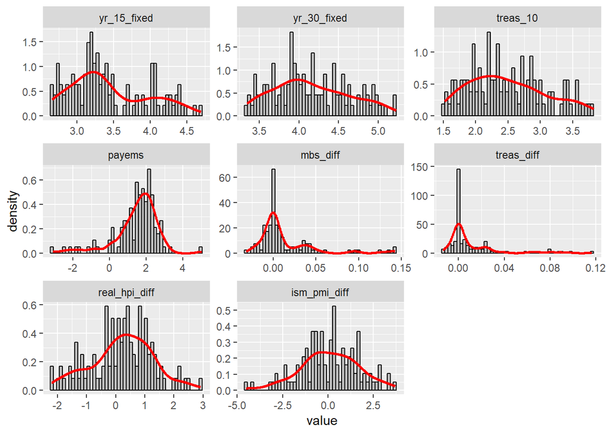

```r
cmb_master2 <- cmb_master2[order(date),]
cmb_master2 <- cmb_master2[-c(1:6)]



### dropping NA values, which was when the Federal Reserve started purchasing MBS products

ggplot(melt(cmb_master2[,-c("date","mbs1","treas1","mix_d","real_hpi","ism_pmi")]),aes(x=value, y = ..density..)) +
  geom_histogram(bins = 50, col="black", fill="grey") +
  stat_density(geom = "line", colour ="red", size = 1) +
  facet_wrap(~variable, scales = "free")
```

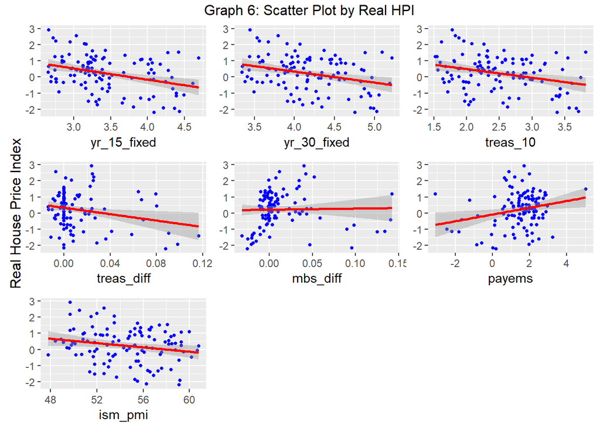

```r
s1 <- ggplot(cmb_master2, aes(x = yr_15_fixed, y = real_hpi_diff)) +
  geom_point(size=1, colour='blue') +
  geom_smooth(method='lm', colour='red')+
  theme(axis.title.y = element_blank())

s2 <- ggplot(cmb_master2, aes(x = yr_30_fixed, y = real_hpi_diff)) +
  geom_point(size=1, colour='blue') +
  geom_smooth(method='lm', colour='red')+
  theme(axis.title.y = element_blank())

s3 <- ggplot(cmb_master2, aes(x = treas_10, y = real_hpi_diff)) +
  geom_point(size=1, colour='blue') +
  geom_smooth(method='lm', colour='red')+
  theme(axis.title.y = element_blank())

s4 <- ggplot(cmb_master2, aes(x = treas_diff, y = real_hpi_diff)) +
  geom_point(size=1, colour='blue') +
  geom_smooth(method='lm', colour='red')+
  theme(axis.title.y = element_blank())

s5 <- ggplot(cmb_master2, aes(x = mbs_diff, y = real_hpi_diff)) +
  geom_point(size=1, colour='blue') +
  geom_smooth(method='lm', colour='red')+
  theme(axis.title.y = element_blank())

s6 <- ggplot(cmb_master2, aes(x = payems, y = real_hpi_diff)) +
  geom_point(size=1, colour='blue') +
  geom_smooth(method='lm', colour='red')+
  theme(axis.title.y = element_blank())

s7 <- ggplot(cmb_master2, aes(x = ism_pmi, y = real_hpi_diff)) +
  geom_point(size=1, colour='blue') +
  geom_smooth(method='lm', colour='red')+
  theme(axis.title.y = element_blank())

grid.arrange(s1,
             s2,
             s3,
             s4,
             s5,
             s6,
             s7,
             ncol = 3, nrow = 3,
             left = textGrob("Real House Price Index", rot = 90, vjust = 1), top=textGrob("Graph 6: Scatter Plot by Real HPI"))
```

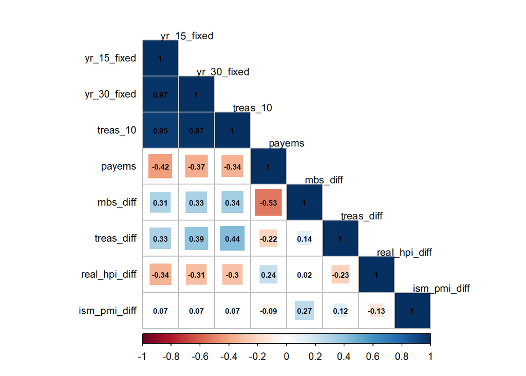

```r
cplot <- cor(cmb_master2[,-c("date","mbs1","treas1","mix_d","real_hpi","ism_pmi")] ,use="pairwise.complete.obs", method = "pearson")
par(mfrow=c(1,1))
corrplot(cplot, method = "square",
         type = "lower", order = "original", number.cex = .6,
         addCoef.col = "black",
         tl.col = "black", tl.srt = 0.1, tl.cex = .8, diag = TRUE)
```

Now that we have numerically and visually described all of our data, we can move onto modeling of our datasets.

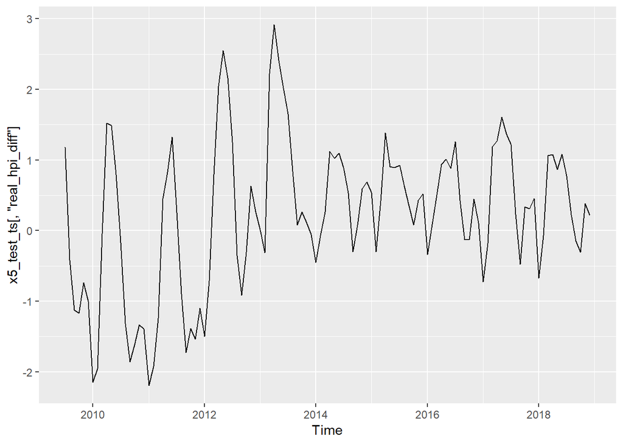

```r
x5_test <- cmb_master2
x5_test$date <- NULL
#x5_test$mix_d <- NULL

x5_test$mbs1<- NULL
x5_test$treas1 <- NULL

# Setting as time-series model
x5_test_ts<-ts(x5_test, start=c(2009, 7), end =c(2018,12), frequency = 12)
arima1 <- auto.arima(x5_test_ts[,"real_hpi_diff"])
autoplot(x5_test_ts[,"real_hpi_diff"])
```

```r
model1 <- tslm(real_hpi_diff ~ mbs_diff + ism_pmi_diff + treas_10 + payems, data = x5_test_ts)
summary(model1)
```

```
##
## Call:
## tslm(formula = real_hpi_diff ~ mbs_diff + ism_pmi_diff + treas_10 +
##     payems, data = x5_test_ts)
##
## Residuals:
##      Min       1Q   Median       3Q      Max
## -2.39048 -0.74085  0.01018  0.68150  2.00528
##
## Coefficients:
##              Estimate Std. Error t value Pr(>|t|)
## (Intercept)   1.07493    0.47801   2.249  0.02654 *
## mbs_diff     10.29662    3.47723   2.961  0.00376 **
## ism_pmi_diff -0.11288    0.06007  -1.879  0.06292 .
## treas_10     -0.53479    0.16981  -3.149  0.00211 **
## payems        0.25260    0.09234   2.736  0.00727 **
## ---
## Signif. codes:  0 '***' 0.001 '**' 0.01 '*' 0.05 '.' 0.1 ' ' 1
##
## Residual standard error: 0.9812 on 109 degrees of freedom
## Multiple R-squared:  0.1837, Adjusted R-squared:  0.1538
## F-statistic: 6.134 on 4 and 109 DF,  p-value: 0.0001725
```

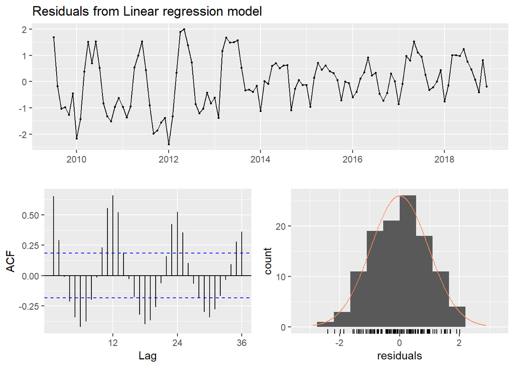

```
##
##  Breusch-Godfrey test for serial correlation of order up to 22
##
## data:  Residuals from Linear regression model
## LM test = 80.779, df = 22, p-value = 1.206e-08
```

```r
checkresiduals(model1, main="Model 1: Linear Reg")
```

```r
model2 <- tslm(real_hpi_diff ~ mbs_diff + ism_pmi_diff + payems + yr_30_fixed, data = x5_test_ts)
summary(model2)
```

```
##
## Call:
## tslm(formula = real_hpi_diff ~ mbs_diff + ism_pmi_diff + payems +
##     yr_30_fixed, data = x5_test_ts)
##
## Residuals:
##      Min       1Q   Median       3Q      Max
## -2.25368 -0.76011 -0.00835  0.66186  2.12009
##
## Coefficients:
##              Estimate Std. Error t value Pr(>|t|)
## (Intercept)   2.48341    0.92118   2.696  0.00813 **
## mbs_diff      9.88360    3.45915   2.857  0.00512 **
## ism_pmi_diff -0.11040    0.06014  -1.836  0.06913 .
## payems        0.24102    0.09335   2.582  0.01115 *
## yr_30_fixed  -0.65385    0.21082  -3.101  0.00245 **
## ---
## Signif. codes:  0 '***' 0.001 '**' 0.01 '*' 0.05 '.' 0.1 ' ' 1
##
## Residual standard error: 0.9824 on 109 degrees of freedom
## Multiple R-squared:  0.1817, Adjusted R-squared:  0.1516
## F-statistic:  6.05 on 4 and 109 DF,  p-value: 0.0001959
```

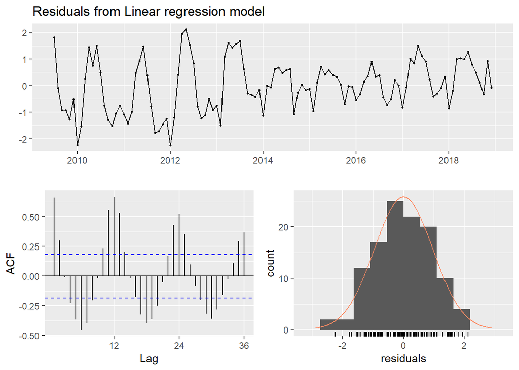

```
##
##  Breusch-Godfrey test for serial correlation of order up to 22
##
## data:  Residuals from Linear regression model
## LM test = 81.653, df = 22, p-value = 8.644e-09
```

```r
checkresiduals(model2, main="Model 2: Linear Reg")
```

```r
model3 <- tslm(real_hpi_diff ~ treas_diff + ism_pmi_diff + yr_15_fixed +payems, data = x5_test_ts)
summary(model3)
```

```
##
## Call:
## tslm(formula = real_hpi_diff ~ treas_diff + ism_pmi_diff + yr_15_fixed +
##     payems, data = x5_test_ts)
##
## Residuals:
##     Min      1Q  Median      3Q     Max
## -2.1399 -0.7419 -0.0543  0.6833  2.5170
##
## Coefficients:
##              Estimate Std. Error t value Pr(>|t|)
## (Intercept)   1.97650    0.75601   2.614   0.0102 *
## treas_diff   -4.87975    4.07712  -1.197   0.2340
## ism_pmi_diff -0.05957    0.05961  -0.999   0.3199
## yr_15_fixed  -0.52643    0.20457  -2.573   0.0114 *
## payems        0.08253    0.08685   0.950   0.3441
## ---
## Signif. codes:  0 '***' 0.001 '**' 0.01 '*' 0.05 '.' 0.1 ' ' 1
##
## Residual standard error: 1.002 on 109 degrees of freedom
## Multiple R-squared:  0.1484, Adjusted R-squared:  0.1172
## F-statistic:  4.75 on 4 and 109 DF,  p-value: 0.00143
```

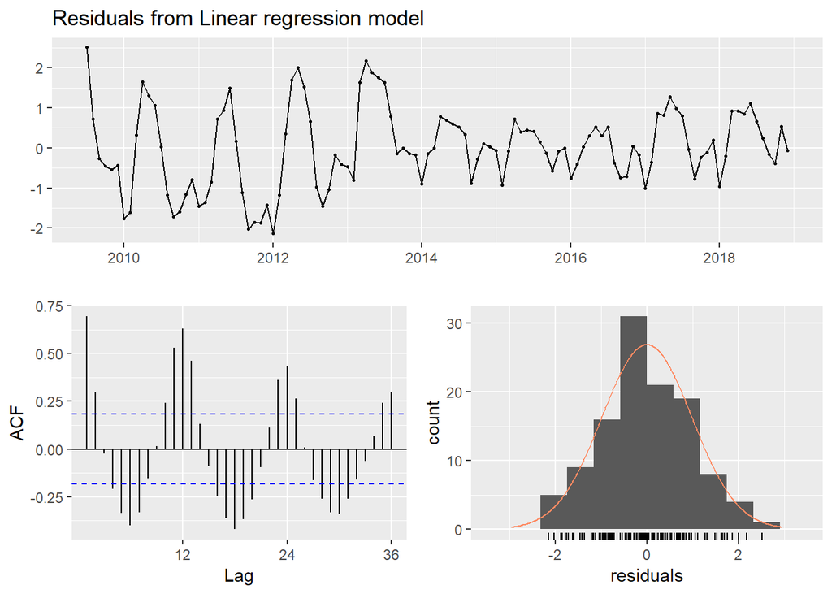

```
##
##  Breusch-Godfrey test for serial correlation of order up to 22
##
## data:  Residuals from Linear regression model
## LM test = 84.012, df = 22, p-value = 3.504e-09
```

```r
checkresiduals(model3, main="Model 3: Linear Reg")
```

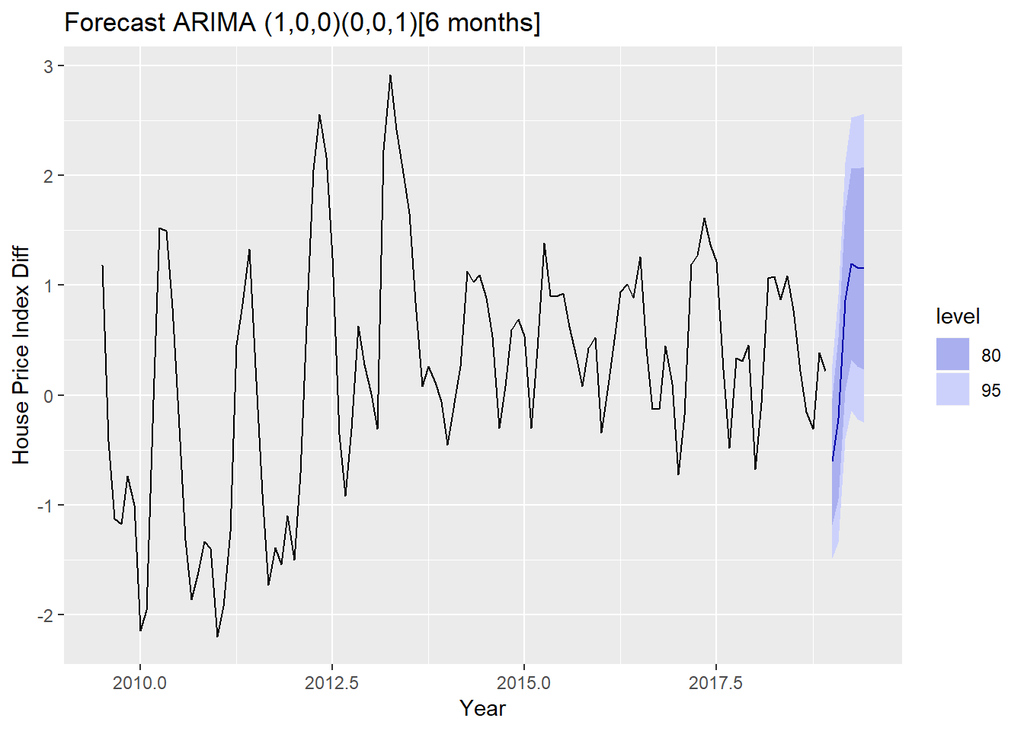

```r
fc1 <- forecast(arima1, h=6) #forecasting 6 months into the future#
autoplot(fc1, scenario=model2) +
ggtitle("Forecast ARIMA (1,0,0)(0,0,1)[6 months]") +
  xlab("Year") +
  ylab("House Price Index Diff")
```

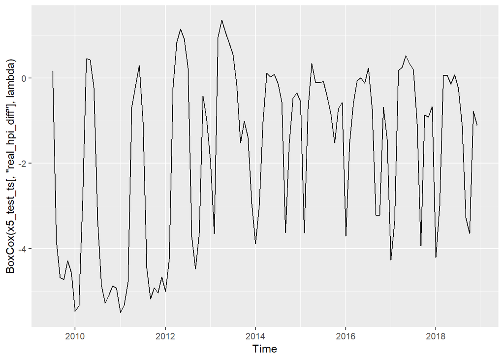

```r
lambda <- BoxCox.lambda(x5_test_ts[,"real_hpi_diff"])
autoplot(BoxCox(x5_test_ts[,"real_hpi_diff"], lambda))
```

```r
lambda
```

```
## [1] 0.4381605
```

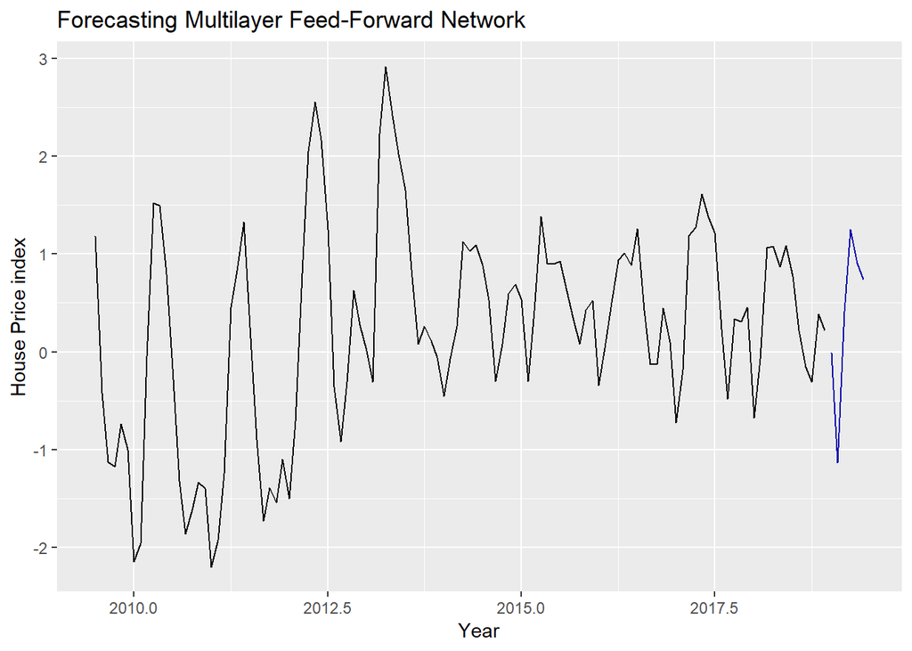

```r
fit1 <- nnetar(x5_test_ts[,"real_hpi_diff"],lambda=.44)
fc2 <- forecast(fit1, h=6)
autoplot(fc2, scenario=model2) + #forecasting 6 months into the future#
  ggtitle("Forecasting Multilayer Feed-Forward Network") +
  xlab("Year") +
  ylab("House Price index")
```

```r
train_clean <- window(x5_test_ts, start=c(2009,7), end=2017)
test_clean <- window(x5_test_ts, start=2017)
model_2_4 <- tslm(real_hpi_diff ~  mbs_diff + ism_pmi_diff + payems + yr_30_fixed, data = train_clean)
summary(model_2_4)
```

```
##
## Call:
## tslm(formula = real_hpi_diff ~ mbs_diff + ism_pmi_diff + payems +
##     yr_30_fixed, data = train_clean)
##
## Residuals:
##      Min       1Q   Median       3Q      Max
## -2.18072 -0.76144 -0.06194  0.70836  2.16668
##
## Coefficients:
##              Estimate Std. Error t value Pr(>|t|)
## (Intercept)   3.07233    1.04626   2.937 0.004258 **
## mbs_diff     12.52145    3.75930   3.331 0.001277 **
## ism_pmi_diff -0.12451    0.07167  -1.737 0.085917 .
## payems        0.23259    0.10076   2.308 0.023384 *
## yr_30_fixed  -0.83072    0.24176  -3.436 0.000911 ***
## ---
## Signif. codes:  0 '***' 0.001 '**' 0.01 '*' 0.05 '.' 0.1 ' ' 1
##
## Residual standard error: 1.019 on 86 degrees of freedom
## Multiple R-squared:  0.2366, Adjusted R-squared:  0.2011
## F-statistic: 6.665 on 4 and 86 DF,  p-value: 0.0001013
```

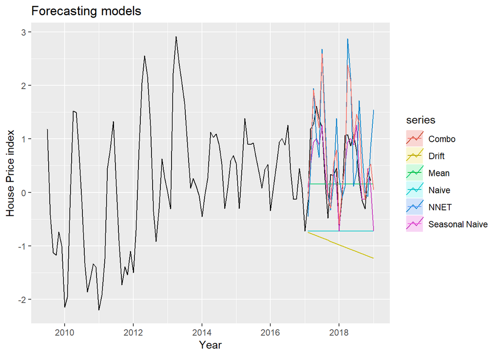

```r
hpi_fit1 <- meanf(train_clean[,"real_hpi_diff"], h=24)
hpi_fit2 <- rwf(train_clean[,"real_hpi_diff"], h=24)
hpi_fit3 <- snaive(train_clean[,"real_hpi_diff"], h=24)
hpi_fit4 <- rwf(train_clean[,"real_hpi_diff"], drift=TRUE, h=24)
lambda2 <- BoxCox.lambda(train_clean[,"real_hpi_diff"])
fit_net <- nnetar(train_clean[,"real_hpi_diff"],lambda=.44)
fc_net <- forecast(fit_net, h=24)
combo <- (hpi_fit3[["mean"]] + fc_net[["mean"]]/2)

autoplot(window(x5_test_ts[,"real_hpi_diff"], start=c(2009,7)))+
  autolayer(hpi_fit1, series="Mean", PI=FALSE)+
  autolayer(hpi_fit2, series="Naive", PI=FALSE)+
  autolayer(hpi_fit3, series="Seasonal Naive", PI=FALSE)+
  autolayer(hpi_fit4, series="Drift", PI=FALSE)+
  autolayer(fc_net, series="NNET", PI=FALSE)+
  autolayer(combo, series="Combo")+
  ggtitle("Forecasting models") +
  xlab("Year") +
  ylab("House Price index")
```

```r
kable(accuracy(hpi_fit1,test_clean[,"real_hpi_diff"]))
```

|  | ME | RMSE | MAE | MPE | MAPE | MASE | ACF1 | Theil’s U |
| --- | --- | --- | --- | --- | --- | --- | --- | --- |
| Training set | 0.0000000 | 1.1335425 | 0.9059222 | 82.09777 | 119.1335 | 1.4345936 | 0.7795223 | NA |
| Test set | 0.3581056 | 0.7291696 | 0.6015788 | 99.74680 | 99.7468 | 0.9526437 | 0.5208312 | 0.8113941 |

```r
kable(accuracy(hpi_fit2,test_clean[,"real_hpi_diff"]))
```

|  | ME | RMSE | MAE | MPE | MAPE | MASE | ACF1 | Theil’s U |
| --- | --- | --- | --- | --- | --- | --- | --- | --- |
| Training set | -0.0211416 | 0.7434115 | 0.5772688 | -40.34108 | 194.3308 | 0.9141471 | 0.3628686 | NA |
| Test set | 1.2381697 | 1.3915864 | 1.2381697 | 101.17286 | 256.4475 | 1.9607316 | 0.5208312 | 1.558813 |

```r
kable(accuracy(hpi_fit3,test_clean[,"real_hpi_diff"]))
```

|  | ME | RMSE | MAE | MPE | MAPE | MASE | ACF1 | Theil’s U |
| --- | --- | --- | --- | --- | --- | --- | --- | --- |
| Training set | 0.1050666 | 0.8237739 | 0.6314835 | 202.56675 | 310.30258 | 1.000000 | 0.7191940 | NA |
| Test set | 0.0758617 | 0.3307393 | 0.2707555 | 30.11068 | 58.65183 | 0.428761 | 0.0557777 | 0.4926435 |

```r
kable(accuracy(hpi_fit4,test_clean[,"real_hpi_diff"]))
```

|  | ME | RMSE | MAE | MPE | MAPE | MASE | ACF1 | Theil’s U |
| --- | --- | --- | --- | --- | --- | --- | --- | --- |
| Training set | 0.000000 | 0.7431108 | 0.575530 | -37.91189 | 191.8595 | 0.9113936 | 0.3628686 | NA |
| Test set | 1.491869 | 1.6105771 | 1.491869 | 104.66395 | 337.5240 | 2.3624826 | 0.4561517 | 1.830083 |

```r
kable(accuracy(fc_net,test_clean[,"real_hpi_diff"]))
```

|  | ME | RMSE | MAE | MPE | MAPE | MASE | ACF1 | Theil’s U |
| --- | --- | --- | --- | --- | --- | --- | --- | --- |
| Training set | 0.0118658 | 0.1600473 | 0.1070910 | 5.290786 | 17.86417 | 0.1695864 | 0.1705380 | NA |
| Test set | -0.2636926 | 0.8946022 | 0.7797185 | -29.310746 | 173.07430 | 1.2347408 | 0.0089861 | 0.8550158 |

```r
kable(accuracy(combo,test_clean[,"real_hpi_diff"]))
```

|  | ME | RMSE | MAE | MPE | MAPE | ACF1 | Theil’s U |
| --- | --- | --- | --- | --- | --- | --- | --- |
| Test set | -0.3131649 | 0.6383444 | 0.4884966 | -34.5447 | 110.6868 | 0.0360689 | 0.4642285 |

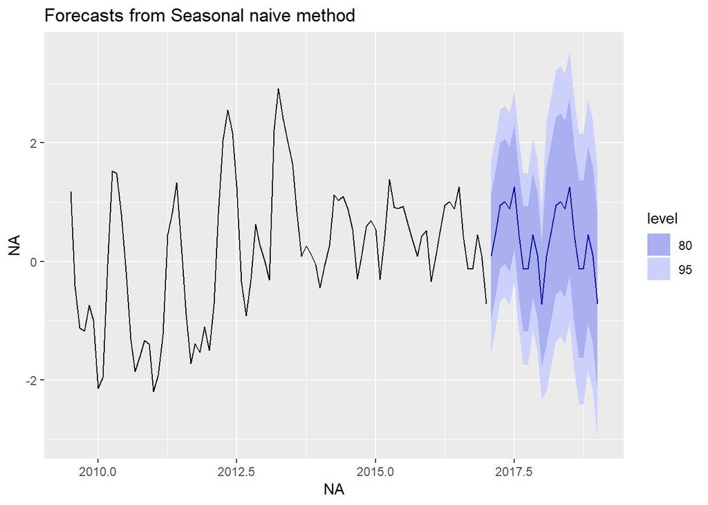

```r
fc_net2 <- forecast(hpi_fit3,PI=TRUE, scenario=model_2_4)
autoplot(fc_net2)
```